# Auditing the COMPAS Score: Predictive Modeling and Algorithmic Fairness

We will be using the dataset at https://github.com/propublica/compas-analysis/raw/master/compas-scores-two-years.csv. Reading it in:

```r
set.seed(0)
compas <- read.csv("https://github.com/propublica/compas-analysis/raw/master/compas-scores-two-years.csv")
```

First, we’ll obtain the set we’ll be working with:

```r
idx <- sample(1:nrow(compas))

idx.train <- idx[1:5000]
idx.test <- idx[5001:6000]
idx.valid <- idx[6001:7000]

compas.train <- compas[idx.train,]
compas.test <- compas[idx.test,]
compas.valid <- compas[idx.valid,]
```

### Part 1: Comparing the scores of black and white defendants

We first explore whether white and black defendants get the same COMPAS scores.

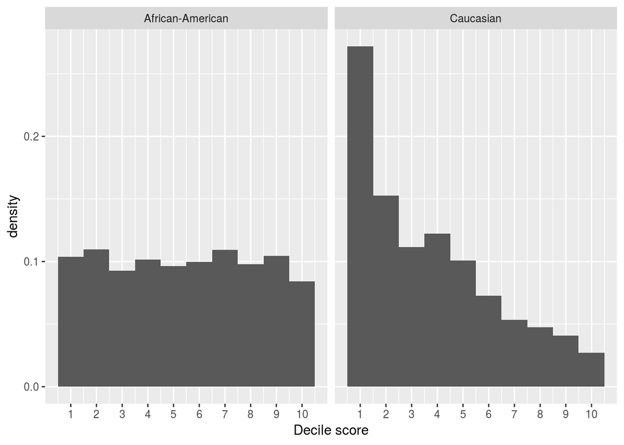

```r
compas.bw <- compas.train %>% filter(race %in% c("African-American", "Caucasian"))

ggplot(compas.bw, mapping = aes(x = decile_score)) +
  geom_histogram(bins = 10, mapping = aes(y = ..density..)) +
  scale_x_continuous(breaks = c(1:10)) +
  facet_wrap(~race)  +
  xlab("Decile score")
```

For African-American defendants, the distribution of the scores is approximately uniform. For Caucasian defendants, many more get low scores than high scores.

### Part 2: Initial evaluation of the COMPAS scores

Here, we are computing the FPR, FNR, and correct classification rate for different populations. First, we’ll define functions to compute the quantities needed.

```r
get.FPR <- function(compas.set, thr){
  return(sum((compas.set$decile_score >= thr) & (compas.set$is_recid == 0))/sum(compas.set$is_recid == 0))
}

get.FNR <- function(compas.set, thr){
  return(sum((compas.set$decile_score < thr) & (compas.set$is_recid == 1))/sum(compas.set$is_recid == 1))
}

get.CCR <- function(compas.set, thr){
  return(mean((compas.set$decile_score >= thr) == compas.set$is_recid))
}
```

Compute the sets we need:

```r
compas.valid.b <- compas.valid %>% filter(race == "African-American")
compas.valid.w <- compas.valid %>% filter(race == "Caucasian")
```

Now, we can compute the numbers:

```r
thr <- 5

fps <- c(get.FPR(compas.valid.b, 5), get.FPR(compas.valid.w, 5), get.FPR(compas.valid, 5))
fns <- c(get.FNR(compas.valid.b, 5), get.FNR(compas.valid.w, 5), get.FNR(compas.valid, 5))
ccr <- c(get.CCR(compas.valid.b, 5), get.CCR(compas.valid.w, 5), get.CCR(compas.valid, 5))

rates <- data.frame(FPR = fps, FNR = fns, CCR = ccr)
rownames(rates) = c("black", "white", "all")
rates
```

```
##             FPR       FNR       CCR
## black 0.4686192 0.3176895 0.6124031
## white 0.2401961 0.5174825 0.6455331
## all   0.3182674 0.3965885 0.6450000
```

We can see that the scores do not satisfy false positive parity and do not satisfy false negative parity. The scores do satisfy classification parity. Demographic parity is also not satisfied.

### Part 3: Altering the threshold

We will now see how changing the threshold influences the false positive, false negative, and correct classification rates.

```r
get.rates <- function(thr, compas.set){
  return(c(get.FPR(compas.set, thr), get.FNR(compas.set, thr), get.CCR(compas.set, thr)))
}

thrs <- seq(0.5, 9.5, 1)
rates.w <- sapply(thrs, FUN=get.rates, compas.valid.w)
rates.b <- sapply(thrs, FUN=get.rates, compas.valid.b)
rates.all <- sapply(thrs, FUN=get.rates, compas.valid)

plot.rates <- function(thrs, rates, caption){
    rates.df <- data.frame(threshold = thrs, FPR = rates[1,], FNR = rates[2,], CCR = rates[3,])
    rates.df.tidy <- melt(rates.df, 1) %>% select(threshold = threshold, measure = variable, rate = value)
    ggplot(rates.df.tidy, mapping = aes(x = threshold, y = rate, color = measure)) +
      geom_smooth(se = F, method = "loess") + labs(title = caption)
}
```

We can now get three figures for the different demographics (let’s forego using facets again):

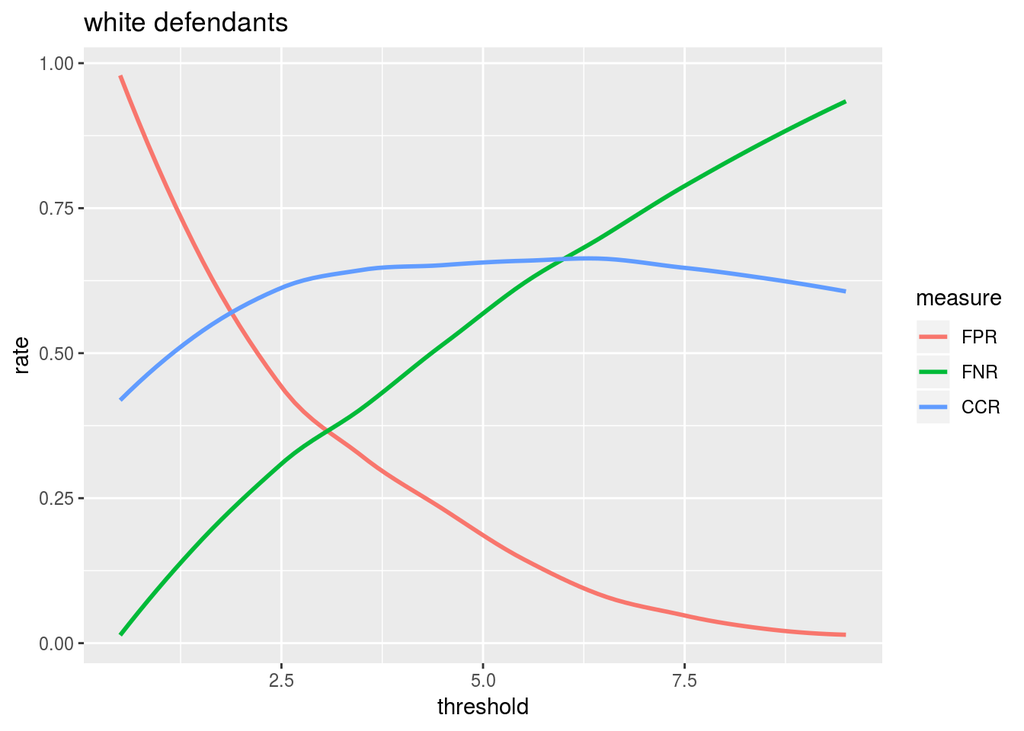

```r
plot.rates(thrs, rates.w, "white defendants")
```

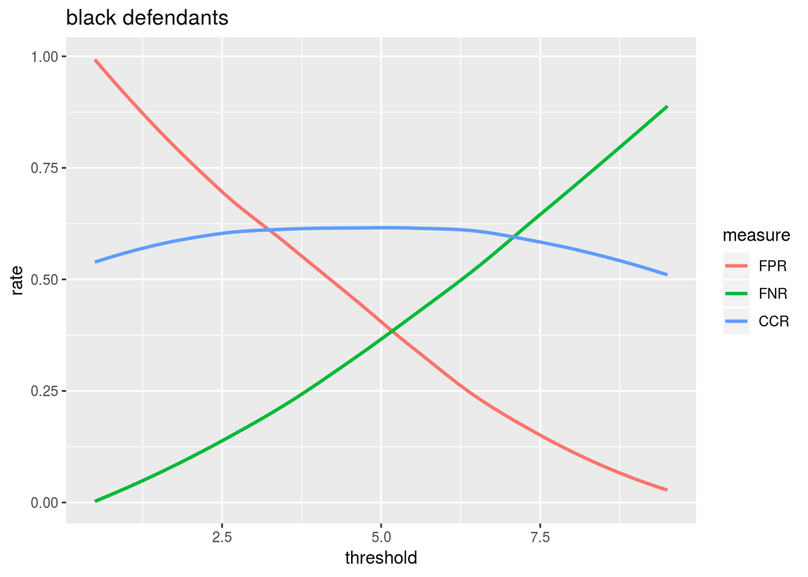

```r
plot.rates(thrs, rates.b, "black defendants")
```

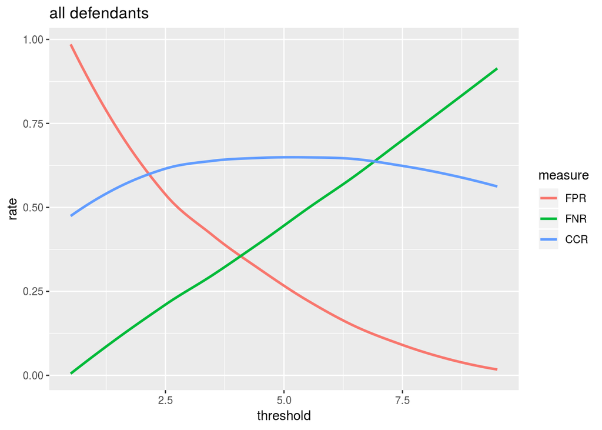

```r
plot.rates(thrs, rates.all, "all defendants")
```

### Part 4: Trying to reproduce the score

Let’s fit the model:

```r
fit <- glm(is_recid ~ age + priors_count, family = binomial, data = compas.train)
fit$coefficients
```

```
##  (Intercept)          age priors_count
##   1.10503459  -0.05058575   0.16915555
```

Let’s now obtain the FPR, FNR, and CCR for our model, using the threshold $0.5$.

```r
get.FPR.fit <- function(thr, compas.set, fit){
  pred <- predict(fit, newdata = compas.set, type = "response") > thr
  return(sum((pred == 1) & (compas.set$is_recid == 0))/sum(compas.set$is_recid == 0))
}


get.FNR.fit <- function(thr, compas.set, fit){
  pred <- predict(fit, newdata = compas.set, type = "response") > thr
  return(sum((pred == 0) & (compas.set$is_recid == 1))/sum(compas.set$is_recid == 1))
}

get.CCR.fit <- function(thr, compas.set, fit){
  pred <- predict(fit, newdata = compas.set, type = "response") > thr
  return(mean(pred == compas.set$is_recid))
}

compas.train.b <- compas.train %>% filter(race == "African-American")
compas.train.w <- compas.train %>% filter(race == "Caucasian")
compas.valid.b <- compas.valid %>% filter(race == "African-American")
compas.valid.w <- compas.valid %>% filter(race == "Caucasian")
thr <- .5

demo.perf.dat.train <- data.frame(FP =  c(get.FPR.fit(thr, compas.train, fit),
                                          get.FPR.fit(thr, compas.train.w, fit),
                                          get.FPR.fit(thr, compas.train.b, fit)),
                                  FN =  c(get.FNR.fit(thr, compas.train, fit),
                                          get.FNR.fit(thr, compas.train.w, fit),
                                          get.FNR.fit(thr, compas.train.b, fit)),
                                  CCR =  c(get.CCR.fit(thr, compas.train, fit),
                                          get.CCR.fit(thr, compas.train.w, fit),
                                          get.CCR.fit(thr, compas.train.b, fit)))

demo.perf.dat.train
```

```
##          FP        FN       CCR
## 1 0.2805728 0.3600993 0.6810000
## 2 0.2102564 0.5072046 0.6662672
## 3 0.3754355 0.2676450 0.6843738
```

```r
demo.perf.dat.valid <- data.frame(FP =  c(get.FPR.fit(thr, compas.valid, fit),
                                          get.FPR.fit(thr, compas.valid.w, fit),
                                          get.FPR.fit(thr, compas.valid.b, fit)),
                                  FN =  c(get.FNR.fit(thr, compas.valid, fit),
                                          get.FNR.fit(thr, compas.valid.w, fit),
                                          get.FNR.fit(thr, compas.valid.b, fit)),
                                  CCR =  c(get.CCR.fit(thr, compas.valid, fit),
                                          get.CCR.fit(thr, compas.valid.w, fit),
                                          get.CCR.fit(thr, compas.valid.b, fit)))

demo.perf.dat.valid
```

```
##          FP        FN       CCR
## 1 0.2768362 0.3752665 0.6770000
## 2 0.1764706 0.5314685 0.6772334
## 3 0.4016736 0.2563177 0.6763566
```

It appears that there is basically no overfitting.

Let’s create the two hypothetical people and predict the probability of re-arrest for both:

```r
dat = data.frame(age = c(30, 30), priors_count = c(2, 3))
predict(fit, newdata = dat, type = "response")
```

```
##         1         2
## 0.4814518 0.5237144
```

### Part 5: Adjusting thresholds

We basically want to find the thresholds for which the false positive rates are at parity. Let’s see what the rates are for different thresholds.

```r
thr <- c(0.3, 0.4, 0.51, 0.52, 0.53, 0.54, 0.55, 0.553, 0.555, 0.558, 0.56, 0.57, 0.58, 0.59, 0.7, 0.8)
fp.rates <- data.frame(thr = thr,
                       FP.b  = sapply(thr, get.FPR.fit, compas.train.b, fit),
                       FP.w = sapply(thr, get.FPR.fit, compas.train.w, fit))

fp.rates
```

```
##      thr       FP.b        FP.w
## 1  0.300 0.82926829 0.609230769
## 2  0.400 0.66811847 0.449230769
## 3  0.510 0.35365854 0.192820513
## 4  0.520 0.30313589 0.160000000
## 5  0.530 0.26742160 0.137435897
## 6  0.540 0.25348432 0.131282051
## 7  0.550 0.22560976 0.110769231
## 8  0.553 0.21080139 0.100512821
## 9  0.555 0.20993031 0.100512821
## 10 0.558 0.20209059 0.093333333
## 11 0.560 0.20034843 0.093333333
## 12 0.570 0.17857143 0.084102564
## 13 0.580 0.17073171 0.078974359
## 14 0.590 0.15766551 0.072820513
## 15 0.700 0.08101045 0.026666667
## 16 0.800 0.04181185 0.008205128
```

We need to tweak the threshold for black defendants just a little:

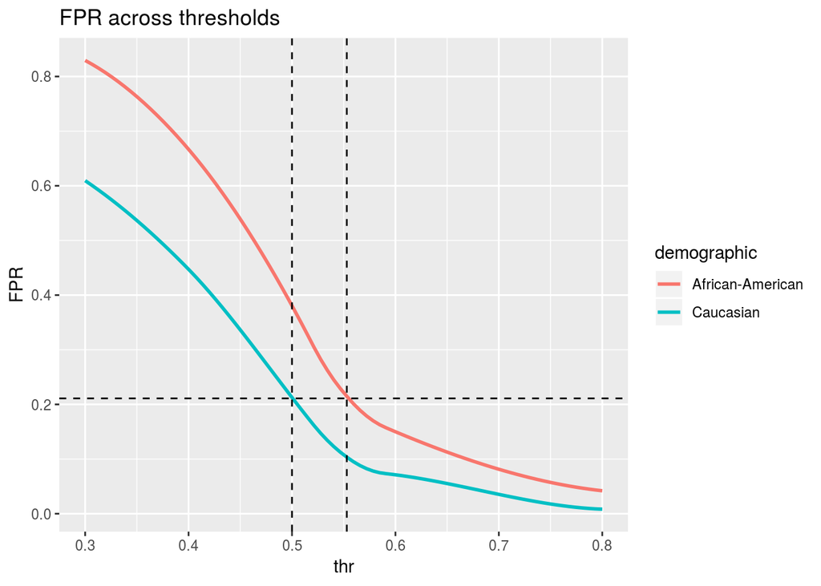

```r
plot.FPR <- function(fp.rates){
  colnames(fp.rates) <- c("thr", "African-American", "Caucasian")
  df.melted <- melt(fp.rates, "thr")
  colnames(df.melted) <- c("thr", "demographic", "FPR")
  ggplot(df.melted) +
    geom_smooth(mapping=aes(x = thr, y = FPR, color = demographic), method = "loess", se = F) +
    geom_vline(xintercept = 0.5, linetype = "dashed") +
    geom_vline(xintercept = 0.553, linetype = "dashed") +
    geom_hline(yintercept = 0.211, linetype = "dashed") +
    ggtitle('FPR across thresholds')
}

plot.FPR(fp.rates)
```

`thr = 0.553` seems about right.

```r
n.correct <- sum(compas.train.b$is_recid == (predict(fit, newdata = compas.train.b, type = "response") > 0.553)) +
             sum(compas.train.w$is_recid == (predict(fit, newdata = compas.train.w, type = "response") > 0.5))
n.total <- nrow(compas.train.b) + nrow(compas.train.w)

n.correct/n.total
```

```
## [1] 0.664548
```

(Note that we ignored everyone who wasn’t white or black. That’s OK to do, but including other demographics (in any way you like) is OK too).